# Lab One

## Riley Sallander

### Task 1

#### 1)

###### X = Income

###### Y = Life Expectancy

###### Size = Population

###### fill = Region

###### year

#### 2)

```python
import pandas as pd
dfQ1 = pd.read_csv("/Users/rileysallander/Desktop/ML/ML554/Data/q1data.csv")
dfQ1 = dfQ1.dropna()
dfQ1.head()
```

|  | income | life_exp | population | year | country | four_regions | six_regions | eight_regions | world_bank_region |
| --- | --- | --- | --- | --- | --- | --- | --- | --- | --- |
| 0 | 1910.0 | 61.0 | 29200000.0 | 2010 | Afghanistan | asia | south_asia | asia_west | South Asia |
| 1 | 11100.0 | 78.1 | 2950000.0 | 2010 | Albania | europe | europe_central_asia | europe_east | Europe & Central Asia |
| 2 | 11100.0 | 74.7 | 36000000.0 | 2010 | Algeria | africa | middle_east_north_africa | africa_north | Middle East & North Africa |
| 3 | 46900.0 | 81.9 | 84500.0 | 2010 | Andorra | europe | europe_central_asia | europe_west | Europe & Central Asia |
| 4 | 7680.0 | 60.8 | 23400000.0 | 2010 | Angola | africa | sub_saharan_africa | africa_sub_saharan | Sub-Saharan Africa |

#### 3)

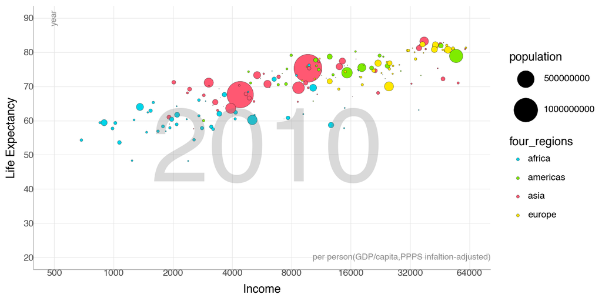

```python
from plotnine import geom_point, ggplot, aes, scale_x_log10,scale_y_continuous,theme_minimal,scale_size_area,scale_fill_manual,theme,annotate, element_blank,element_line,labs,scale_x_continuous,scale_y_log10
#basic graph aes assignments
(ggplot(dfQ1,
aes(
  x = "income",
  y = "life_exp",
  fill = "four_regions",
  size = "population"
))

# Scale the graph and sizes of bubbles along with colors
+ geom_point(color='black', stroke = 0.1)
+ scale_x_log10(breaks=[500,1000,2000,4000,8000,16000,32000,64000],limits=(500, 64000))
+ scale_y_continuous(breaks=[10,20,30,40,50,60,70,80,90],limits=(20, 90))
+ scale_size_area(max_size=15)
+ scale_fill_manual(values={
        'asia': '#ff5872',
        'europe': '#ffe700',
        'americas': '#7feb00',
        'africa': '#00d5e9',
    })

# Add themes and gridlines
+ theme_minimal()
+ theme(figure_size=(8, 4))
+ theme(panel_grid_minor=element_blank(),
        panel_grid_major=element_line(size=0.5),
        axis_line=element_line(size=0.5, color='grey',alpha = 0.8))

# Add axis lables and background 2010
+ annotate('text', x=6000, y=50, label='2010', size=100, color='grey', alpha=0.3, angle=0)
+ annotate('text', x=29000, y=20, label='per person(GDP/capita,PPPS infaltion-adjusted)', size=8, color='grey', alpha=0.9, angle=0)
+ annotate('text', x=500, y=90, label='year', size=8, color='grey', alpha=0.9, angle=90)

# Label the Axis
+ labs(
  x='Income',
  y='Life Expectancy'
  )
)
```

#### 4)

For an alternative graph I chose to create a density plot comparing the life expectancy of each region more specifically. This is an interesting plot to look at as it allows for a more general picture of the life expecancy in each region. Europe for example stands out being mostly higher than the other regions. There are issues with this visualization as it loses out on information that the bubble chart contains like income and population. It instead is a better view into one specific variable.

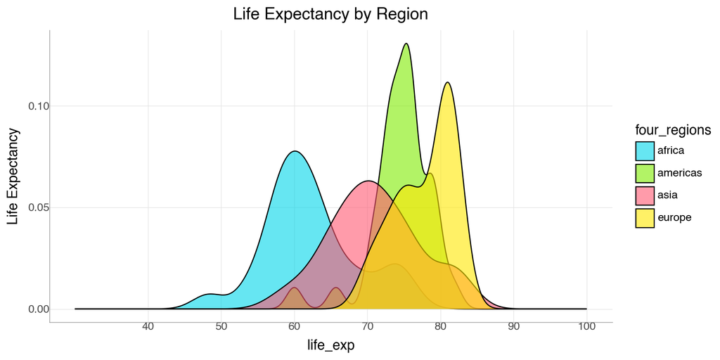

```python
from plotnine import geom_density

(ggplot(dfQ1, aes(x='life_exp', fill='four_regions'))
+geom_density(alpha=0.6)
+labs(title='Life Expectancy by Region', y='Life Expectancy')
+theme_minimal()  # Clean theme for better visualization

+ scale_x_continuous(breaks=[40,50,60,70,80,90,100],limits=(30,100))
+ scale_fill_manual(values={
        'asia': '#ff5872',
        'europe': '#ffe700',
        'americas': '#7feb00',
        'africa': '#00d5e9',
    })


+ theme(figure_size=(8, 4))
+ theme(panel_grid_minor=element_blank(),
        panel_grid_major=element_line(size=0.5),
        axis_line=element_line(size=0.5, color='grey',alpha = 0.8))

)
```

### Task 2

#### 1)

###### X = Exports

###### Y = Imports

###### Size = Energy

###### fill = Region

###### year

#### 2)

### Task 2

#### 1)

###### X = Export %

###### Y = Import %

###### Size = Energy Use

###### fill = Region

#### 2)

```python
dfQ2 = pd.read_csv("/Users/rileysallander/Desktop/ML/ML554/Data/q2data.csv")

dfQ2=dfQ2.dropna()

## converted thousand denoted with k to floats (consulted chatgpt on this one)
def convert_energy(value):
    if 'k' in value:
        return float(value.replace('k', '').strip()) * 1000
    else:
        return float(value)

dfQ2['energy'] = dfQ2['energy'].apply(convert_energy)

dfQ2.head()

dfQ2
```

|  | imports | exports | energy | year | country | four_regions | six_regions | eight_regions | world_bank_region |
| --- | --- | --- | --- | --- | --- | --- | --- | --- | --- |
| 1 | 36.7 | 11.5 | 427.0 | 1997 | Albania | europe | europe_central_asia | europe_east | Europe & Central Asia |
| 2 | 22.5 | 22.6 | 825.0 | 1997 | Algeria | africa | middle_east_north_africa | africa_north | Middle East & North Africa |
| 6 | 12.9 | 10.4 | 1660.0 | 1997 | Argentina | americas | america | america_south | Latin America & Caribbean |
| 7 | 52.8 | 19.0 | 610.0 | 1997 | Armenia | europe | europe_central_asia | europe_east | Europe & Central Asia |
| 9 | 20.5 | 19.6 | 5550.0 | 1997 | Australia | asia | east_asia_pacific | east_asia_pacific | East Asia & Pacific |
| ... | ... | ... | ... | ... | ... | ... | ... | ... | ... |
| 198 | 22.9 | 22.6 | 2080.0 | 1997 | Uzbekistan | asia | europe_central_asia | asia_west | Europe & Central Asia |
| 200 | 22.7 | 20.9 | 2250.0 | 1997 | Venezuela | americas | america | america_south | Latin America & Caribbean |
| 201 | 52.2 | 44.8 | 340.0 | 1997 | Vietnam | asia | east_asia_pacific | east_asia_pacific | East Asia & Pacific |
| 204 | 31.6 | 24.6 | 617.0 | 1997 | Zambia | africa | sub_saharan_africa | africa_sub_saharan | Sub-Saharan Africa |
| 205 | 45.1 | 43.4 | 845.0 | 1997 | Zimbabwe | africa | sub_saharan_africa | africa_sub_saharan | Sub-Saharan Africa |

127 rows × 9 columns

#### 3)

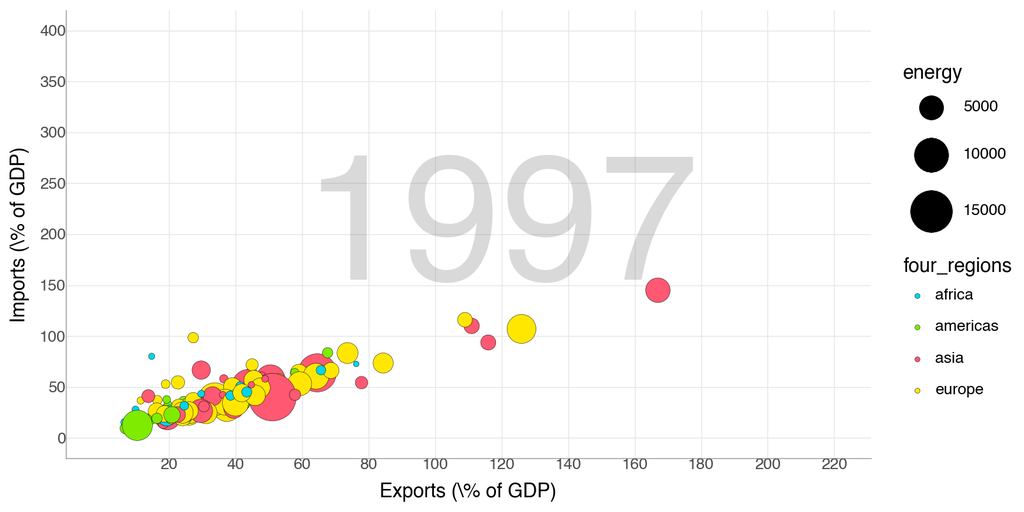

```python
(ggplot(dfQ2,
aes(
  x = "exports",
  y = "imports",
  fill = "four_regions",
  size = "energy"
))

# Scale the graph and sizes of bubbles along with colors
+ geom_point(color='black', stroke = 0.1)
+ scale_x_continuous(breaks=[20,40,60,80,100,120,140,160,180,200,220],limits=(0,220))
+ scale_y_continuous(breaks=[0,50,100,150,200,250,300,350,400],limits=(0, 400))
+ scale_size_area(max_size=15)
+ scale_fill_manual(values={
        'asia': '#ff5872',
        'europe': '#ffe700',
        'americas': '#7feb00',
        'africa': '#00d5e9',
    })
# Add themes and gridlines
+ theme_minimal()
+ theme(figure_size=(8, 4))
+ theme(panel_grid_minor=element_blank(),
        panel_grid_major=element_line(size=0.5),
        axis_line=element_line(size=0.5, color='grey',alpha = 0.8))

# Add axis lables and background 2010
+ annotate('text', x=120, y=200, label='1997', size=100, color='grey', alpha=0.3, angle=0)

# Label the Axis
+ labs(
  x='Exports (\% of GDP)',
  y='Imports (\% of GDP)'
  )
)
```

#### 4)

For this alternative visualization I created a boxplot of each regions % exports. This gives a better insight into region based exports but loses information in energy and specific countries within a region. This gives a better overview of region behavior but does not provide specific inishgts.

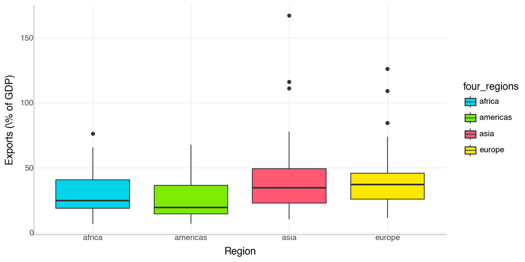

```python
from plotnine import geom_boxplot

(ggplot(dfQ2,
        aes(x="four_regions", y="exports", fill="four_regions"))
+ geom_boxplot()
+ scale_fill_manual(values={
        'asia': '#ff5872',
        'europe': '#ffe700',
        'americas': '#7feb00',
        'africa': '#00d5e9',
    })

+ theme_minimal()
+ theme(figure_size=(8, 4))
+ theme(panel_grid_minor=element_blank(),
        panel_grid_major=element_line(size=0.5),
        axis_line=element_line(size=0.5, color='grey',alpha = 0.8))

+ labs(
  x='Region',
  y='Exports (\% of GDP)'
  )


)
```

### Task 2

#### 1)

###### X = Internet Usage %

###### Y = GDP

###### Size = Income

###### fill = Region

###### year

#### 2)

```python
dfQ3 = pd.read_csv("/Users/rileysallander/Desktop/ML/ML554/Data/q3data.csv")

dfQ3=dfQ3.dropna()

dfQ3.head()
```

|  | internet_users | gdp | income | year | country | four_regions | six_regions | eight_regions | world_bank_region |
| --- | --- | --- | --- | --- | --- | --- | --- | --- | --- |
| 0 | 0.00456 | 330.0 | 1190.0 | 2001 | Afghanistan | asia | south_asia | asia_west | South Asia |
| 1 | 0.39000 | 2570.0 | 6780.0 | 2001 | Albania | europe | europe_central_asia | europe_east | Europe & Central Asia |
| 2 | 1.59000 | 3770.0 | 9230.0 | 2001 | Algeria | africa | middle_east_north_africa | africa_north | Middle East & North Africa |
| 4 | 11.30000 | 42600.0 | 35600.0 | 2001 | Andorra | europe | europe_central_asia | europe_west | Europe & Central Asia |
| 5 | 0.27000 | 2440.0 | 2900.0 | 2001 | Angola | africa | sub_saharan_africa | africa_sub_saharan | Sub-Saharan Africa |

#### 3)

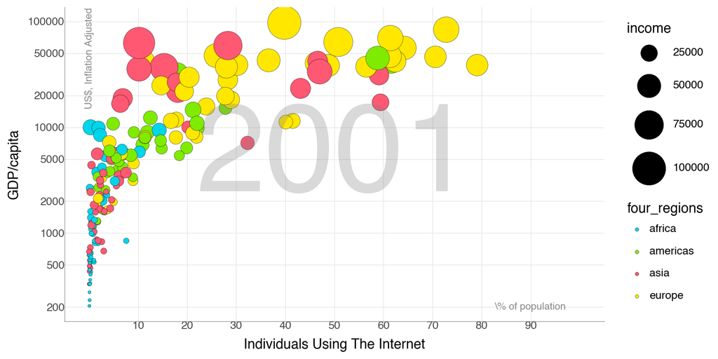

```python
(ggplot(dfQ3,
aes(
  x = "internet_users",
  y = "gdp",
  fill = "four_regions",
  size = "income"
))

# Scale the graph and sizes of bubbles along with colors
+ geom_point(color='black', stroke = 0.1)
+ scale_x_continuous(breaks=[10,20,30,40,50,60,70,80,90],limits=(0,100))
+ scale_y_log10(breaks=[200,500,1000,2000,5000,10000,20000,50000,100000],limits=(200, 100000))
+ scale_size_area(max_size=15)
+ scale_fill_manual(values={
        'asia': '#ff5872',
        'europe': '#ffe700',
        'americas': '#7feb00',
        'africa': '#00d5e9',
    })

# Add themes and gridlines
+ theme_minimal()
+ theme(figure_size=(8, 4))
+ theme(panel_grid_minor=element_blank(),
        panel_grid_major=element_line(size=0.5),
        axis_line=element_line(size=0.5, color='grey',alpha = 0.8))

# Add axis lables and background 2010
+ annotate('text', x=50, y=5000, label='2001', size=100, color='grey', alpha=0.3, angle=0)
+ annotate('text', x=90, y=200, label='\% of population', size=8, color='grey', alpha=0.9, angle=0)
+ annotate('text', x=0, y=45000, label='US$, Inflation Adjusted', size=8, color='grey', alpha=0.9, angle=90)

# Label the Axis
+ labs(
  x='Individuals Using The Internet',
  y='GDP/capita'
  )
)
```

#### 4)

For this alternative data vizualization I created a heat map representing internet using % on the x axis and GDP on the y axis, while the heat was the count of occurance within each bin. The majority of the density is found in the lower left corner likely as small countries have smaller gdp and less people using the internet. This is not a great representation of the data as some of it is lost, like region and income, while not providing better insight. From the previous bubble chart you can see density through the bubble clustering while still retaining the lost information.

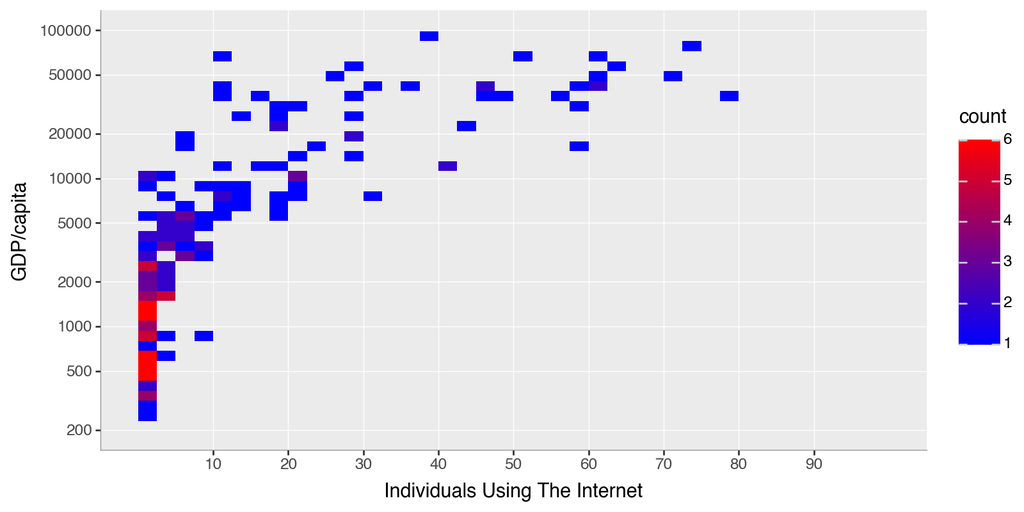

```python
from plotnine import geom_bin2d, scale_fill_gradient

(ggplot(dfQ3,
        aes(x="internet_users", y="gdp"))
 + geom_bin2d(bins=40)
+ scale_x_continuous(breaks=[10,20,30,40,50,60,70,80,90],limits=(0,100))
+ scale_y_log10(breaks=[200,500,1000,2000,5000,10000,20000,50000,100000],limits=(200, 100000))

 + scale_fill_gradient(low="blue", high="red")

 # Add themes and gridlines
+ theme(figure_size=(8, 4))
+ theme(panel_grid_minor=element_blank(),
        panel_grid_major=element_line(size=0.5),
        axis_line=element_line(size=0.5, color='grey',alpha = 0.8))

# Label the Axis
+ labs(
  x='Individuals Using The Internet',
  y='GDP/capita'
  )
)
```